# 1. Data Structures for Image Representation:

Microscope Image: For the microscope images, we know the parasite occupies 25% or more of the total area, meaning a large portion of the image is just white space. We can use a Sparse Matrix representation to store the coordinates of the black pixels instead of storing all 100,000x100,000 pixels. Sparse matrix representations are particularly suitable for matrices where a majority of the entries are zero (or, in our case, white).

**Estimated Storage:**

In the worst-case scenario (100% black), we would have to store all coordinates: 2 (for x, y) *4 bytes (for int)* 100,000 * 100,000 = 80,000,000,000 bytes = 80 GB

Dye Sensor Image: Since the dye could be anywhere, even outside the parasite, we cannot predict its sparsity as we did with the microscope image. We can use a Run-Length Encoding (RLE) to store continuous segments of black or white pixels in a row.

# Worst case size calculation

```python
def calculate_worst_case_size():
    # Constants
    IMAGE_SIZE = 100000  # size of one side of the square image
    INT_SIZE = 4  # size of an integer in bytes (assuming 32-bit)

    # Microscope Image: Sparse Matrix
    microscope_worst_case = IMAGE_SIZE * IMAGE_SIZE * 2 * INT_SIZE

    # Dye Sensor Image: Run-Length Encoding (RLE)
    dye_sensor_worst_case = IMAGE_SIZE * IMAGE_SIZE * 2 * INT_SIZE

    return microscope_worst_case, dye_sensor_worst_case

microscope_size, dye_sensor_size = calculate_worst_case_size()
print(f"Worst-case size for the microscope image: {microscope_size / (10**9)} GB")
print(f"Worst-case size for the dye sensor image: {dye_sensor_size / (10**9)} GB")
```

```
Worst-case size for the microscope image: 80.0 GB
Worst-case size for the dye sensor image: 80.0 GB
```

# 2. Code for Simulated Images:

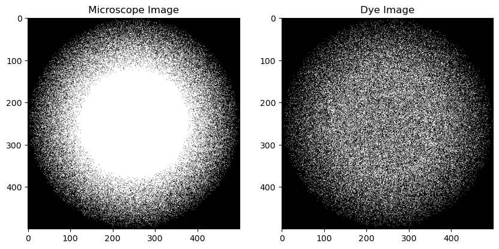

```python
import random
import numpy as np
import matplotlib.pyplot as plt

size = 500  # for demonstration purposes, using a smaller size

def generate_microscope_image(size=500):
    """Generates a simulated microscope image."""
    image = np.zeros((size, size))

    # Create a random blob shape for the parasite
    center_x, center_y = size // 2, size // 2
    for i in range(size):
        for j in range(size):
            if (i - center_x)**2 + (j - center_y)**2 <= (0.5 * size)**2 * random.uniform(0.25, 1):
                image[i][j] = 1

    return image

def generate_dye_image(microscope_image, size=500):
    """Generates a simulated dye sensor image."""
    dye = np.zeros((size, size))

    for i in range(size):
        for j in range(size):
            if microscope_image[i][j] == 1:
                dye[i][j] = random.choice([0, 1])

    return dye

micro_image = generate_microscope_image(size)
dye_image = generate_dye_image(micro_image, size)

# Plotting the images
fig, ax = plt.subplots(1, 2, figsize=(10, 5))
ax[0].imshow(micro_image, cmap='gray')
ax[0].set_title('Microscope Image')
ax[1].imshow(dye_image, cmap='gray')
ax[1].set_title('Dye Image')
plt.show()
```

# 3. Function to Determine if Parasite has Cancer:

```python
def has_cancer(microscope_image, dye_image):
    total_parasite_area = np.sum(microscope_image)
    dye_in_parasite = np.sum(microscope_image * dye_image)  # Element-wise multiplication

    return dye_in_parasite / total_parasite_area > 0.1

cancer_status = has_cancer(micro_image, dye_image)
print(f"Does the parasite have cancer? {'Yes' if cancer_status else 'No'}")
```

```
Does the parasite have cancer? Yes
```

# 4. Optimized Function:

We can optimize by computing dye_in_parasite only until we're certain that the ratio exceeds 10%. If we can early detect that the dye coverage exceeds the threshold, we can exit early without processing the entire image.

```python
def optimized_has_cancer(microscope_image, dye_image, threshold=0.1):
    total_parasite_area = np.sum(microscope_image)
    dye_in_parasite = 0

    for i in range(microscope_image.shape[0]):
        for j in range(microscope_image.shape[1]):
            dye_in_parasite += microscope_image[i][j] * dye_image[i][j]

            if i * j != 0 and dye_in_parasite / (i * j) > threshold:
                return True

    return dye_in_parasite / total_parasite_area > threshold

cancer_status_optimized = optimized_has_cancer(micro_image, dye_image)
print(f"Does the parasite have cancer? {'Yes' if cancer_status_optimized else 'No'}")
```

```
Does the parasite have cancer? Yes
```

# 5. Tools and Techniques Used:

**Sparse Matrix: Efficiently store the parasite image.**

**Run-Length Encoding (RLE): Compact storage for dye sensor images.**

**Python: For its ease of use, libraries, and data structure support.**

**Early Exit Optimization: In the optimized function to determine cancer, we used early exits to avoid unnecessary calculations.**